# Prognose der Besucherzahlen des Europäischen Hansemuseums in Lübeck

# Management Summary

# 1 Allgemeine Projektinformationen

## 1.1 Ausgangslage

Dieses R Projekt ist ein Teil des Projektes „Künstliche Intelligenz in Einrichtungen der kulturellen Infrastruktur“. Das Projekt wird von der Fachhochschule Kiel zur Digitalisierung von Kulturinstitutionen und besonders zur Forschung zum Einsatz von künstlicher Intelligenz in Kulturinstitutionen im Marketing, der Verwaltung und zur Verbesserung des Angebotes durchgeführt. Gefördert wird das Vorhaben durch die Staatskanzlei des Landes Schleswig-Holstein. Zu den Kooperationspartnern zählen die schleswig-holsteinische Landesbibliothek (SHLB), das Europäische Hansemuseum Lübeck (EHM) und das Nordkolleg Rendsburg. Weitere Informationen zu dem Projekt finden Sie unter:

- https://www.fh-kiel-gmbh.de/de/leistungen/drittmittelprojekte/landesministerien-sh/ki-in-kultur.html
- https://www.schleswig-holstein.de/DE/Landesregierung/I/_startseite/Artikel2020/I/200211_CDS_Foerderbescheid-landesbibliothek.html

Ein Teilaspekt das Europäische Hansemuseum betreffend ist die Prognose der Besucherzahlen.

Die Prognose von Umsätzen (/Besucherzahlen) des [Europäischen Hansemuseums](https://www.hansemuseum.eu/) (EHM) ist bislang seitens der Institution nicht behandelt worden. Eine systematische Planung unter Einbeziehung von Mustern findet nicht statt, wenngleich das EHM daran sehr interessiert ist.

## 1.2 Zielsetzung

Es werden verschiedene einfache und komplexe Modelle getestet, dabei werden auch Techniken aus den Bereichen Machine Learning und Deep Learning angewendet.

**Lösungsansatz**

Mit Hilfe von verschiedenen Daten und Einflussfaktoren sollen die Umsätze des EHM prognostiziert werden. Einbezogen werden dabei Umsatzdaten, Wetterdaten, Veranstaltungsdaten sowie weitere Einflussfaktoren wie beispielsweise die Wochentage, Feiertage, Ferientage.

## 1.3 Datenbasis

Seitens des EHM wurden Daten aus ihrem Kassensystem für die Jahre 2015 bis 2020 zur Verfügung gestellt. Das EHM arbeitet an dieser Stelle mit dem Unternehmen [Beckerbillet](https://www.beckerbillett.de/de/Museen_und_Science_Center.html) zusammen, dessen “Kompetenz sich aus der Kombination einer modernen Ticketdruckerei mit einem spezialisierten Softwarehaus und dem durchdachten Hardware-Angebot ergibt”. Es stehen sowohl Umsatzdaten als auch Besucherzahlen vor.

Weiterhin wurden folgende Daten für die Analyse potentieller Einflussfaktoren recherchiert bzw. erhoben und jeweils ein Datensatz erstellt:

- Wetterdaten
  - maximale Temperatur
  - minimale Temperatur
  - Durchschnittstemperatur
  - Niederschlag (mm)
  - Sonnenstunden
  - Windstärke (Beaufort)
- Daten zur Kieler Woche
- Daten zu Ferientagen in den Bundesländern
  - Baden-Württemberg
  - Bayern
  - Hessen
  - Niedersachsen
  - Nordrhein-Westfalen
  - Schleswig-Holstein
- Daten zu Feiertagen
  - Ostern
  - Christi Himmelfahrt
  - Pfingsten
  - Tag der Deutschen Einheit
  - Weihnachten
- Daten zu Silvester
- Daten zu den Jahreszeiten.

Im weiteren Verlauf werden all diese Datensätze zusammengefügt und dieser Datensatz wiederum um die Variablen Wochentag, monat und Jahr ergänzt, was nicht zuletzt der Aufteilung in Trainings- und Testdatensatz dient.

# 2 Datenexploration

## 2.1 Einlesen der Daten

Im ersten Schritt müssen die Daten zunächst eingelesen werden um sie bearbeiten zu können:

```r
# mit read_csv einlesen um eine Veränderung der Datentypen (bzw. eine Faktorisierung) zu verhindern!
library(readxl)
Umsatz <- read_excel("Daten/Umsatz.xlsx")
Tickets <- read_excel("Daten/Tickets.xlsx")
```

## 2.2 Überprüfung der Datenstrukturen

```r
str(Umsatz)
```

```
## tibble [1,747 x 3] (S3: tbl_df/tbl/data.frame)
##  $ Datum    : POSIXct[1:1747], format: "2015-05-29" "2015-05-30" ...
##  $ Wochentag: chr [1:1747] "Freitag" "Samstag" "Sonntag" "Montag" ...
##  $ Umsatz   : num [1:1747] 0 0 34.5 31 0 0 17 8 13 20.5 ...
```

```r
glimpse(Umsatz)
```

```
## Rows: 1,747
## Columns: 3
## $ Datum     <dttm> 2015-05-29, 2015-05-30, 2015-05-31, 2015-06-01, 2015-06-...
## $ Wochentag <chr> "Freitag", "Samstag", "Sonntag", "Montag", "Dienstag", "M...
## $ Umsatz    <dbl> 0.0, 0.0, 34.5, 31.0, 0.0, 0.0, 17.0, 8.0, 13.0, 20.5, 0....
```

```r
range(Umsatz$Umsatz)
```

```
## [1]    0 8728
```

Der Datensatz **Umsatz** ist ein Dataframe, enthält 1747 Zeilen und 3 Variablen:

- Datum (`dttm`)
- Wochentag (`chr`)
- Umsatz (`dbl`) mit Werten zwischen 0 und 8728 €.
- Datensatz **Tickets**

```r
str(Tickets)
```

```
## tibble [1,747 x 3] (S3: tbl_df/tbl/data.frame)
##  $ Datum    : POSIXct[1:1747], format: "2015-05-29" "2015-05-30" ...
##  $ Wochentag: chr [1:1747] "Freitag" "Samstag" "Sonntag" "Montag" ...
##  $ Tickets  : num [1:1747] 0 8 11 2 0 4 2 3 10 0 ...
```

```r
glimpse(Tickets)
```

```
## Rows: 1,747
## Columns: 3
## $ Datum     <dttm> 2015-05-29, 2015-05-30, 2015-05-31, 2015-06-01, 2015-06-...
## $ Wochentag <chr> "Freitag", "Samstag", "Sonntag", "Montag", "Dienstag", "M...
## $ Tickets   <dbl> 0, 8, 11, 2, 0, 4, 2, 3, 10, 0, 2, 5, 4, 7, 2, 12, 7, 7, ...
```

```r
range(Tickets$Tickets)
```

```
## [1]    0 1108
```

Der Datensatz **Tickets** enthält ebenfalls 1747 Zeilen und die Variablen Datum (`dttm`), Wochentag (`chr`) und Tickets (`dbl`) mit Werten zwischen 0 und 1108.

## 2.3 Überprüfung des Anfangs- und Endzeitpunkt der Datumsattribute in den Datensätzen

```r
range(Umsatz$Datum)
```

```
## [1] "2015-05-29 UTC" "2020-03-14 UTC"
```

```r
range(Tickets$Datum)
```

```
## [1] "2015-05-29 UTC" "2020-03-14 UTC"
```

Die Daten beider Datensätze reichen vom 29.05.2015 bis 14.03.2020.

## 2.4 Überprüfung der Datensätze auf fehlende Werte

### Überprüfung auf “klassische” fehlende Werte (NA)

Zunächst einmal wird geprüft, welche klassischen fehlenden Werte (NA) in den einzelnen Datensätzen vorhanden sind:

```r
sum(is.na(Umsatz))
```

```
## [1] 0
```

```r
sum(is.na(Tickets))
```

```
## [1] 0
```

Die Datensätze sind vollständig.

> Anmerkung: Vollständig im Sinne von es gibt keine fehlenden Werte in der Tabelle. Es gibt einen Tag, an dem das Museum nicht geöffnet hat und der dementsprechend fehlt (24.12. Heiligabend).

## 2.5 Überprüfung der Datensätze auf Ausreißer

Ein Ausreißer ist ein Wert, der außerhalb der üblichen Struktur einer Verteilung liegt. Zunächst wird in einem ersten Schritt mittels einer Visualisierung in Form von `boxplots` überprüft, ob die einzelnen Datensätze überhaupt Ausreißer enthalten.

Ein Boxplot zeigt uns den Median (dicke Linie) sowie das untere und obere Quartil (als Box). Der Abstand von unterem zu oberem Quartil (interquartile range: IQR) wird standardmäßig mit 1.5 multipliziert. Und genau über die auf diese Art ermittelte Spannweite erstrecken sich die sogenannten whiskers maximal, wobei die whiskers unten und oben an der Box ansetzen. Gibt es darüber hinaus noch Werte, die weiter außerhalb liegen, werden diese als Ausreißer durch Punkte gekennzeichnet.

Die Überprüfung wird begonnen mit dem Datensatz **Umsatz**:

```r
# Überprüfung der Variable Umsatz
summary(Umsatz$Umsatz)
```

```
##    Min. 1st Qu.  Median    Mean 3rd Qu.    Max.
##       0    1094    1783    1804    2384    8728
```

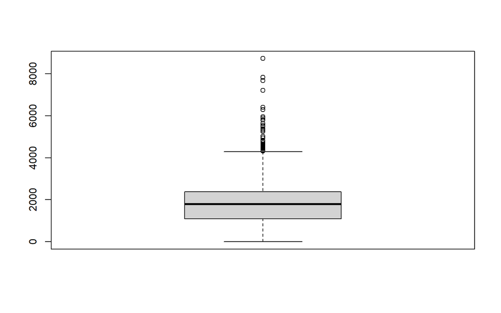

```r
boxplot(Umsatz$Umsatz)
```

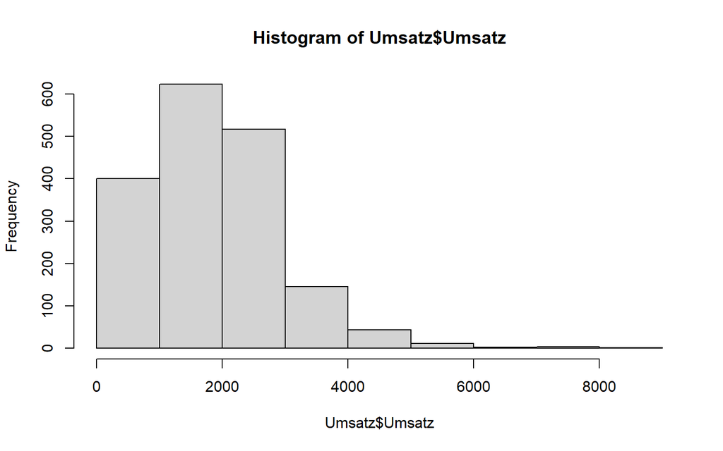

```r
hist(Umsatz$Umsatz)
```

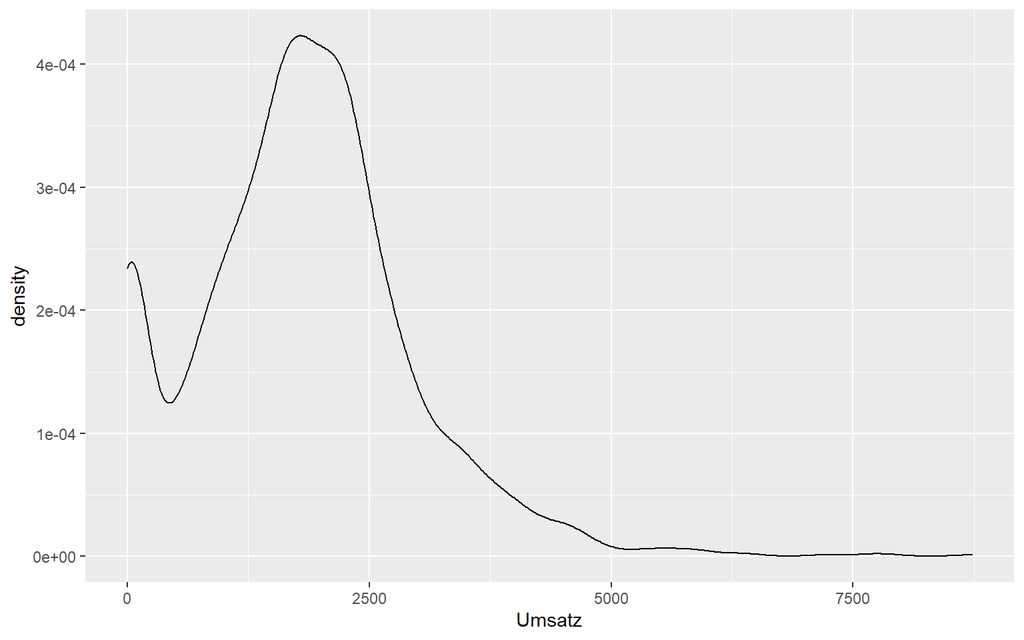

```r
# Visualisierung
Umsatz %>%
  dplyr::select(Umsatz) %>%
  ggplot(aes(Umsatz)) +
  geom_density()
```

Das Attribut `Umsatz` enthält zahlreiche Ausreißer. Mit bloßem Auge ist nicht zu erkennen, wie viele Ausreißer es genau sind. Die Ausreißer werden also in einem 2. Schritt genauer betrachtet, um die genaue Anzahl der Ausreißer zu ermitteln. Statistiker haben viele Verfahren entwickelt, um auseinanderzuhalten, was man als Ausreißer bezeichnen sollte, und was nicht.

Wir verwenden - wie bereits erwähnt - die Standardeinstellung, die aus einer Definition von John W. Tukey stammt: Sie definiert einen Ausreißer als einen Punkt, der mehr als
$$1,5 * IQR$$
vom unteren bzw. oberen Quartil abweicht. Anders gesagt liegen untere Ausreißer unterhalb

$$Q_1 - 1,5 * IQR$$
und obere Ausreißer oberhalb

$$Q_3 + 1.5 * IQR$$

Vereinfachend untersuchen wir nun die Umsatzvariable insgesamt auf Ausreißer:

```r
g_oben <- quantile(Umsatz$Umsatz, probs=0.75) + (1.5*IQR(Umsatz$Umsatz)) #Obere Grenze fuer Ausreißer
g_oben
```

```
##      75%
## 4319.188
```

```r
Umsatz %>%
  dplyr::select(Umsatz) %>%
  filter(Umsatz > g_oben) %>%
  summarise(n = n())
```

```
## # A tibble: 1 x 1
##       n
##   <int>
## 1    41
```

In einem 3. Schritt betrachten wir, an welchen Daten diese Ausreißer auftreten und ob Muster erkennbar sind (z. B. überproportional hohe Umsätze an Ostern oder anderen Feiertagen, in den Ferien, während der Kieler Woche o. Ä.):

```r
Umsatz %>%
  dplyr::select(Datum, Umsatz) %>%
  filter(Umsatz > g_oben)
```

```
## # A tibble: 41 x 2
##    Datum               Umsatz
##    <dttm>               <dbl>
##  1 2015-07-20 00:00:00  8728
##  2 2015-07-22 00:00:00  4794.
##  3 2015-07-26 00:00:00  5629
##  4 2015-07-27 00:00:00  5542.
##  5 2015-07-28 00:00:00  5893
##  6 2015-07-29 00:00:00  7840.
##  7 2015-07-30 00:00:00  7672
##  8 2015-07-31 00:00:00  7209
##  9 2015-08-01 00:00:00  4586.
## 10 2015-08-20 00:00:00  4812.
## # ... with 31 more rows
```

Eine erste Auswertung der genaueren Betrachtung der Ausreißer ergibt:

**Fazit**

Einen besonderen Stellenwert scheinen die Feiertage Ostern und Pfingsten zu haben. Auch am Tag der Deutschen Einheit scheinen die Umsätze generell tendenziell hoch zu sein. Ansonsten sieht man einen relativ klaren “Sommer-Effekt”.

Da die meisten Ausreißer planbar und plausibel erscheinen, werden diese zunächst in der Auswertung belassen. Zu überlegen ist jedoch, ob der “Eröffnungseffekt” nicht eliminiert werden sollte, da dieser schon starken Einfluss übt.

Die Überprüfung wird weitergeführt mit dem Datensatz **Tickets**:

```r
# Überprüfung der Variable Umsatz
summary(Tickets$Tickets)
```

```
##    Min. 1st Qu.  Median    Mean 3rd Qu.    Max.
##     0.0   125.0   212.0   214.2   283.0  1108.0
```

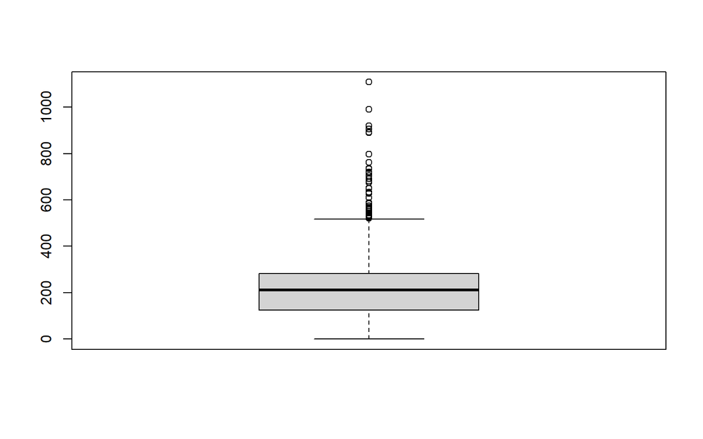

```r
boxplot(Tickets$Tickets)
```

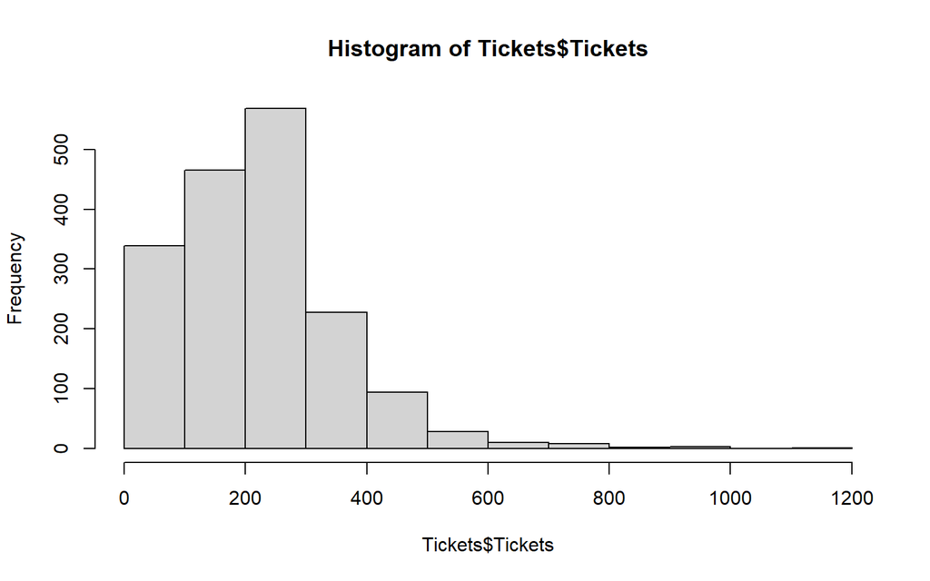

```r
hist(Tickets$Tickets)
```

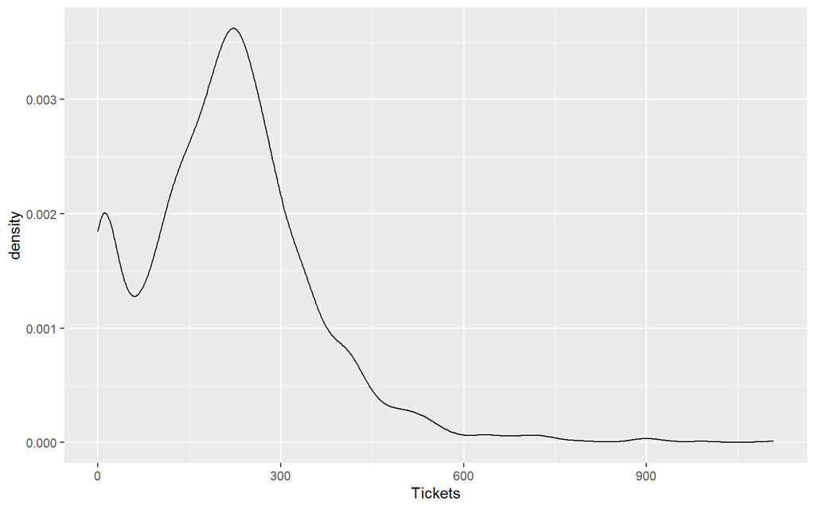

```r
# Visualisierung
Tickets %>%
  dplyr::select(Tickets) %>%
  ggplot(aes(Tickets)) +
  geom_density()
```

Das Attribut `Tickets` enthält erwartungsgemäß ebenfalls zahlreiche Ausreißer. Mit bloßem Auge ist nicht zu erkennen, wie viele Ausreißer es genau sind. Die Ausreißer werden also in einem 2. Schritt genauer betrachtet, um die genaue Anzahl der Ausreißer zu ermitteln. Statistiker haben viele Verfahren entwickelt, um auseinanderzuhalten, was man als Ausreißer bezeichnen sollte, und was nicht.

Wir verwenden - wie bereits erwähnt - die Standardeinstellung, die aus einer Definition von John W. Tukey stammt: Sie definiert einen Ausreißer als einen Punkt, der mehr als
$$1,5 * IQR$$
vom unteren bzw. oberen Quartil abweicht. Anders gesagt liegen untere Ausreißer unterhalb

$$Q_1 - 1,5 * IQR$$
und obere Ausreißer oberhalb

$$Q_3 + 1.5 * IQR$$

```r
g_oben <- (quantile(Tickets$Tickets, probs=0.75) + (1.5*IQR(Tickets$Tickets))) #Obere Grenze fuer Ausreißer
g_oben
```

```
## 75%
## 520
```

```r
Tickets %>%
  dplyr::select(Tickets) %>%
  filter(Tickets > g_oben) %>%
  summarise(n = n())
```

```
## # A tibble: 1 x 1
##       n
##   <int>
## 1    46
```

Die obere Grenze für Ausreißer liegt demzufolge bei 520 Tickets. Es gibt insgesamt 46 Ausreißer in der Variable `Tickets`, also 5 mehr als bei der Variable `Umsatz`.

In einem 3. Schritt betrachten wir, an welchen Daten diese Ausreißer auftreten und ob Muster erkennbar sind (z. B. überproportional hohe Umsätze an Ostern oder anderen Feiertagen, in den Ferien, während der Kieler Woche o. Ä.):

```r
Tickets %>%
  dplyr::select(Datum, Tickets) %>%
  filter(Tickets > g_oben)
```

```
## # A tibble: 46 x 2
##    Datum               Tickets
##    <dttm>                <dbl>
##  1 2015-07-19 00:00:00     991
##  2 2015-07-25 00:00:00     628
##  3 2015-07-26 00:00:00     630
##  4 2015-07-27 00:00:00     681
##  5 2015-07-28 00:00:00     905
##  6 2015-07-29 00:00:00     891
##  7 2015-07-30 00:00:00     798
##  8 2015-07-31 00:00:00     526
##  9 2015-08-19 00:00:00     550
## 10 2016-01-02 00:00:00     561
## # ... with 36 more rows
```

Eine erste Auswertung der genaueren Betrachtung der Ausreißer ergibt:

**Fazit**

Einen besonderen Einfluss scheint es abermals bei den Feiertagen rund um Ostern und Pfingsten zu geben, wenngleich der Effekt teilweise hinsichtlich des konkreten Tages anders ist als beim Umsatz. Weiterhin sieht man wie bei der Analyse der Umsatzdaten einen “Sommereffekt”.

# 3 Datenaufbereitung, Erstellung von Rohdatensatz und Analysedatensätzen

## 3.1 Vereinigung der Datensätze

Maßgeblich ist in diesem Projekt der Zeitraum, in dem Umsatzdaten bzw. Besucherzahlen seitens des Hansemuseums vorliegen. Diese Daten liegen für den Zeitraum 29.05.2015 bis 14.03.2020 vor (vgl. Kap. 2.3.). Über`left_join`-Operationen werden nun weitere erhobene Daten an den Umsatzdatensatz sowie den Ticketdatensatz angefügt.

```r
# Importieren aller weiteren vorliegenden Daten:
library(readr)
ChristiHimmelfahrt <- read_csv2("Daten/ChristiHimmelfahrt.csv")
```

```
## Using ',' as decimal and '.' as grouping mark. Use read_delim() for more control.
```

```r
ChristiHimmelfahrt_ext <- read_excel("Daten/ChristiHimmelfahrt_ext.xlsx")
Feiertage <- read_csv2("Daten/Feiertage.csv")
```

```
## Using ',' as decimal and '.' as grouping mark. Use read_delim() for more control.
```

```r
Fruehling <- read_csv2("Daten/Fruehling.csv")
```

```
## Using ',' as decimal and '.' as grouping mark. Use read_delim() for more control.
```

```r
Herbst <- read_csv2("Daten/Herbst.csv")
```

```
## Using ',' as decimal and '.' as grouping mark. Use read_delim() for more control.
```

```r
Jahreszeiten <- read_csv2("Daten/Jahreszeiten.csv")
```

```
## Using ',' as decimal and '.' as grouping mark. Use read_delim() for more control.
```

```r
KiWo <- read_csv("Daten/KiWo.csv")
Ostern <- read_csv2("Daten/Ostern.csv")
```

```
## Using ',' as decimal and '.' as grouping mark. Use read_delim() for more control.
```

```r
Ostern_ext <- read_csv2("Daten/Ostern_extended.csv")
```

```
## Using ',' as decimal and '.' as grouping mark. Use read_delim() for more control.
```

```r
Pfingsten <- read_csv2("Daten/Pfingsten.csv")
```

```
## Using ',' as decimal and '.' as grouping mark. Use read_delim() for more control.
```

```r
Pfingsten_ext <- read_csv2("Daten/Pfingsten_ext.csv")
```

```
## Using ',' as decimal and '.' as grouping mark. Use read_delim() for more control.
```

```r
Silvester <- read_csv2("Daten/Silvester.csv")
```

```
## Using ',' as decimal and '.' as grouping mark. Use read_delim() for more control.
```

```r
Silvester_ext <- read_csv2("Daten/Silvester_ext.csv")
```

```
## Using ',' as decimal and '.' as grouping mark. Use read_delim() for more control.
```

```r
SoFe_BW <- read_csv2("Daten/SoFe_BW.csv")
```

```
## Using ',' as decimal and '.' as grouping mark. Use read_delim() for more control.
```

```r
SoFe_BY <- read_csv2("Daten/SoFe_BY.csv")
```

```
## Using ',' as decimal and '.' as grouping mark. Use read_delim() for more control.
```

```r
SoFe_HE <- read_csv2("Daten/SoFe_HE.csv")
```

```
## Using ',' as decimal and '.' as grouping mark. Use read_delim() for more control.
```

```r
SoFe_NDS <- read_csv2("Daten/SoFe_NDS.csv")
```

```
## Using ',' as decimal and '.' as grouping mark. Use read_delim() for more control.
```

```r
SoFe_NRW <- read_csv2("Daten/SoFe_NRW.csv")
```

```
## Using ',' as decimal and '.' as grouping mark. Use read_delim() for more control.
```

```r
SoFe_SH <- read_csv2("Daten/SoFe_SH.csv")
```

```
## Using ',' as decimal and '.' as grouping mark. Use read_delim() for more control.
```

```r
Sommer <- read_csv2("Daten/Sommer.csv")
```

```
## Using ',' as decimal and '.' as grouping mark. Use read_delim() for more control.
```

```r
TDE <- read_csv2("Daten/TdDE.csv")
```

```
## Using ',' as decimal and '.' as grouping mark. Use read_delim() for more control.
```

```r
Weihnachten <- read_csv2("Daten/Weihnachten.csv")
```

```
## Using ',' as decimal and '.' as grouping mark. Use read_delim() for more control.
```

```r
Winter <- read_csv2("Daten/Winter.csv")
```

```
## Using ',' as decimal and '.' as grouping mark. Use read_delim() for more control.
```

```r
Wetter <- read_csv2("Daten/Wetterdaten.csv")
```

```
## Using ',' as decimal and '.' as grouping mark. Use read_delim() for more control.
```

```r
# Vereinigung der Datensätze
df_complete <- left_join(Umsatz, ChristiHimmelfahrt, by = "Datum")
df_complete <- left_join(df_complete, ChristiHimmelfahrt_ext, by = "Datum")
df_complete <- left_join(df_complete, Feiertage, by = "Datum")
df_complete <- left_join(df_complete, Fruehling, by = "Datum")
df_complete <- left_join(df_complete, Herbst, by = "Datum")
df_complete <- left_join(df_complete, Jahreszeiten, by = "Datum")
df_complete <- left_join(df_complete, KiWo, by = "Datum")
df_complete <- left_join(df_complete, Ostern, by = "Datum")
df_complete <- left_join(df_complete, Ostern_ext, by = "Datum")
df_complete <- left_join(df_complete, Pfingsten, by = "Datum")
df_complete <- left_join(df_complete, Pfingsten_ext, by = "Datum")
df_complete <- left_join(df_complete, Silvester, by = "Datum")
df_complete <- left_join(df_complete, Silvester_ext, by = "Datum")
df_complete <- left_join(df_complete, SoFe_BW, by = "Datum")
df_complete <- left_join(df_complete, SoFe_BY, by = "Datum")
df_complete <- left_join(df_complete, SoFe_HE, by = "Datum")
df_complete <- left_join(df_complete, SoFe_NDS, by = "Datum")
df_complete <- left_join(df_complete, SoFe_NRW, by = "Datum")
df_complete <- left_join(df_complete, SoFe_SH, by = "Datum")
df_complete <- left_join(df_complete, Sommer, by = "Datum")
df_complete <- left_join(df_complete, TDE, by = "Datum")
df_complete <- left_join(df_complete, Weihnachten, by = "Datum")
df_complete <- left_join(df_complete, Winter, by = "Datum")
df_complete <- left_join(df_complete, Wetter, by = "Datum")
head(df_complete)
```

```
## # A tibble: 6 x 33
##   Datum               Wochentag Umsatz ChristiHimmelfa~ ChristiHimmelfa~
##   <dttm>              <chr>      <dbl>            <dbl>            <dbl>
## 1 2015-05-29 00:00:00 Freitag      0                 NA               NA
## 2 2015-05-30 00:00:00 Samstag      0                 NA               NA
## 3 2015-05-31 00:00:00 Sonntag     34.5               NA               NA
## 4 2015-06-01 00:00:00 Montag      31                 NA               NA
## 5 2015-06-02 00:00:00 Dienstag     0                 NA               NA
## 6 2015-06-03 00:00:00 Mittwoch     0                 NA               NA
## # ... with 28 more variables: Feiertag <dbl>, Fruehling <dbl>, Herbst <dbl>,
## #   Jahreszeit <chr>, KielerWoche <dbl>, Ostern <dbl>, Ostern_ext <dbl>,
## #   Pfingsten <dbl>, Pfingsten_ext <dbl>, Silvester <dbl>, Silvester_ext <dbl>,
## #   SommerferienBaW <dbl>, SommerferienBY <dbl>, SommerferienHE <dbl>,
## #   SommerferienNDS <dbl>, SommerferienNRW <dbl>, SommerferienSH <dbl>,
## #   Sommer <dbl>, TDE <dbl>, Weihnachten <dbl>, Winter <dbl>, Tmax <chr>,
## #   Tmittel <chr>, Tmin <chr>, Tminboden <chr>, Niederschlag_mm <chr>,
## #   Sonnenstunden <chr>, Wind_bft <dbl>
```

## 3.6 Umgang mit fehlenden Werten

Die Datensätze enthalten “naturimmanent” viele fehlende Werte, die beim Import automatisch erzeugt wurden. Beispielsweise enthält der Datensatz **KiWo** nur 72 Datensätze: für jedes Jahr wurde den Tagen, an denen die KiWo stattfindet, eine 1 zugeordnet. Diese Werte wurden Bei der Vereinigung der Datensätze entsprechend korrekt gemerged. Für alle anderen Daten, an denen keine KiWo ist, wurde bei der Vereinigung ein fehlender Wert (NA) automatisch erzeugt. Diese fehlenden Werte sind für die weitergehenden Analysen durch “0” zu ersetzen, sodass eine binäre (0/1)-Variable entsteht. Genauso wird bei den anderen Variablen, die auf Basis der eigens recherchierten Daten erstellt wurden, vorgegangen:

```r
df_complete <- df_complete %>%
  mutate(ChristiHimmelfahrt = replace_na(ChristiHimmelfahrt, 0)) %>%
  mutate(ChristiHimmelfahrt_ext = replace_na(ChristiHimmelfahrt_ext, 0)) %>%
  mutate(Feiertag = replace_na(Feiertag, 0)) %>%
  mutate(Fruehling = replace_na(Fruehling, 0)) %>%
  mutate(Herbst = replace_na(Herbst, 0)) %>%
  mutate(KielerWoche = replace_na(KielerWoche, 0)) %>%
  mutate(Ostern = replace_na(Ostern, 0)) %>%
  mutate(Ostern_ext = replace_na(Ostern_ext, 0)) %>%
  mutate(Pfingsten = replace_na(Pfingsten, 0)) %>%
  mutate(Pfingsten_ext = replace_na(Pfingsten_ext, 0)) %>%
  mutate(Silvester = replace_na(Silvester, 0)) %>%
  mutate(Silvester_ext = replace_na(Silvester_ext, 0)) %>%
  mutate(SommerferienBaW = replace_na(SommerferienBaW, 0)) %>%
  mutate(SommerferienBY = replace_na(SommerferienBY, 0)) %>%
  mutate(SommerferienHE = replace_na(SommerferienHE, 0)) %>%
  mutate(SommerferienNDS = replace_na(SommerferienNDS, 0)) %>%
  mutate(SommerferienNRW = replace_na(SommerferienNRW, 0)) %>%
  mutate(SommerferienSH = replace_na(SommerferienSH, 0)) %>%
  mutate(Sommer = replace_na(Sommer, 0)) %>%
  mutate(TDE = replace_na(TDE, 0)) %>%
  mutate(Weihnachten = replace_na(Weihnachten, 0)) %>%
  mutate(Winter = replace_na(Winter, 0))

head(df_complete)
```

```
## # A tibble: 6 x 33
##   Datum               Wochentag Umsatz ChristiHimmelfa~ ChristiHimmelfa~
##   <dttm>              <chr>      <dbl>            <dbl>            <dbl>
## 1 2015-05-29 00:00:00 Freitag      0                  0                0
## 2 2015-05-30 00:00:00 Samstag      0                  0                0
## 3 2015-05-31 00:00:00 Sonntag     34.5                0                0
## 4 2015-06-01 00:00:00 Montag      31                  0                0
## 5 2015-06-02 00:00:00 Dienstag     0                  0                0
## 6 2015-06-03 00:00:00 Mittwoch     0                  0                0
## # ... with 28 more variables: Feiertag <dbl>, Fruehling <dbl>, Herbst <dbl>,
## #   Jahreszeit <chr>, KielerWoche <dbl>, Ostern <dbl>, Ostern_ext <dbl>,
## #   Pfingsten <dbl>, Pfingsten_ext <dbl>, Silvester <dbl>, Silvester_ext <dbl>,
## #   SommerferienBaW <dbl>, SommerferienBY <dbl>, SommerferienHE <dbl>,
## #   SommerferienNDS <dbl>, SommerferienNRW <dbl>, SommerferienSH <dbl>,
## #   Sommer <dbl>, TDE <dbl>, Weihnachten <dbl>, Winter <dbl>, Tmax <chr>,
## #   Tmittel <chr>, Tmin <chr>, Tminboden <chr>, Niederschlag_mm <chr>,
## #   Sonnenstunden <chr>, Wind_bft <dbl>
```

## 3.7 Ergänzung um die Variablen Wochentag, Monat und Jahr

Ein wesentlicher Einflussfaktor für die Prognose der Besucherzahlen wird der Wochentag sein. Diese Spalten werden in einem weiteren Schritt hinzugefügt. Es wird also der Wochentag als eigene Spalte hinzugefügt: Sonntag (1), Montag (2), … , Samstag (7); und für die spätere Aufteilung der Daten in Training- und Testset wird das Jahr als weitere Spalte ergänzt und der Monat.

Damit die Wochentage adäquat in die späteren Modelle einfließen können, wird der Wochentag überdies als `character`-Variable abgespeichert.

Bsp.: Soll der `Wochentag` ein lineare Regressionsmodell aufgenommen werden, würde eine numerische Variable zu falschen Ergebnissen führen (wird der Wochentag um eins erhöht, erhöht sich der Umsatz um xy%). Bei einer `character`-Variable würde diese “dummyfiziert”. Ein Wochentag würde als Referenztag abgebildet werden und die anderen 6 Wochentage in Form von Dummyvariablen.

```r
df_complete <- df_complete %>% mutate(Wochentag = wday(Datum))
df_complete <- df_complete %>% mutate(Jahr = year(Datum))
df_complete <- df_complete %>% mutate(Monat = month(Datum))

# Wochentag als character-Variable
df_complete <- df_complete %>% mutate(Wochentag_c = recode(Wochentag, "1" = "Sonntag", "2" = "Montag", "3" = "Dienstag", "4" = "Mittwoch", "5" = "Donnerstag", "6" = "Freitag", "7" = "Samstag"))

# Monat als character-Variable
df_complete <- df_complete %>% mutate(Monat_c = recode(Monat, "1" = "Januar", "2" = "Februar", "3" = "März", "4" = "April", "5" = "Mai", "6" = "Juni", "7" = "Juli", "8" = "August", "9" = "September", "10" = "Oktober", "11" = "November", "12" = "Dezember"))
```

Es besteht die Möglichkeit, dass es unterhalb der Wochentag keine großen Unterschiede gibt, wohl aber zwischen Wochentagen und Wochenendtagen. Insofern wird eine weitere Variable `Wochenende` erstellt, die nur die beiden Ausprägungen 1 = “Wochenende” und 0 = “kein Wochenende” (“Wochentag”) hat.

```r
df_complete <- df_complete %>% mutate(Wochenende = recode(Wochentag, "1" = "1", "2" = "0", "3" = "0", "4" = "0", "5" = "0", "6" = "0", "7" = "1"))

df_complete <- df_complete %>% mutate(Wochenende = as.numeric(Wochenende))
```

# 4 Deskriptive Analysen

## 4.1 Analyse des Umsatzes

### Die 20 umsatzstärksten Tage im betrachteten Zeitraum (Gesamtumsatz pro Tag)

```r
Umsatz %>%
  dplyr::select(Datum, Umsatz) %>%
  group_by(Datum) %>%
  summarise(Gesamtumsatz = sum(Umsatz)) %>%
  arrange(desc(Gesamtumsatz)) %>%
  top_n(20)
```

```
## # A tibble: 20 x 2
##    Datum               Gesamtumsatz
##    <dttm>                     <dbl>
##  1 2015-07-20 00:00:00        8728
##  2 2015-07-29 00:00:00        7840.
##  3 2015-07-30 00:00:00        7672
##  4 2015-07-31 00:00:00        7209
##  5 2016-05-16 00:00:00        6407
##  6 2016-08-04 00:00:00        6290.
##  7 2016-03-26 00:00:00        5958.
##  8 2015-07-28 00:00:00        5893
##  9 2017-07-13 00:00:00        5820.
## 10 2017-07-26 00:00:00        5796.
## 11 2015-07-26 00:00:00        5629
## 12 2015-07-27 00:00:00        5542.
## 13 2019-08-16 00:00:00        5487
## 14 2017-06-05 00:00:00        5384.
## 15 2017-04-16 00:00:00        5322.
## 16 2019-08-19 00:00:00        5254.
## 17 2016-10-23 00:00:00        5020.
## 18 2017-09-10 00:00:00        4950
## 19 2016-01-03 00:00:00        4817
## 20 2019-08-08 00:00:00        4815
```

### Gesamtumsatz und Umsatz je Wochentag

Zunächst wird der Umsatz je Wochentag in den Daten untersucht. Als Basis verwenden wir die zunächst den vollständigen Datensatz `df_complete`.

```r
df_complete %>% summarise(Umsatz_sum = sum(Umsatz))
```

```
## # A tibble: 1 x 1
##   Umsatz_sum
##        <dbl>
## 1   3152010.
```

```r
df_complete %>% group_by(Wochentag_c) %>% summarise(Umsatz_sum = sum(Umsatz)) %>% arrange(desc(Umsatz_sum))
```

```
## # A tibble: 7 x 2
##   Wochentag_c Umsatz_sum
##   <chr>            <dbl>
## 1 Sonntag        601301.
## 2 Montag         509619.
## 3 Samstag        441110.
## 4 Donnerstag     430616.
## 5 Freitag        422653.
## 6 Mittwoch       410566.
## 7 Dienstag       336145.
```

```r
df_complete %>% group_by(Wochenende) %>% summarise(Umsatz_sum = sum(Umsatz)) %>% arrange(desc(Umsatz_sum))
```

```
## # A tibble: 2 x 2
##   Wochenende Umsatz_sum
##        <dbl>      <dbl>
## 1          0   2109599.
## 2          1   1042411.
```

```r
df_complete %>% group_by(Wochentag_c) %>% summarise(Umsatz_mean = mean(Umsatz)) %>% arrange(desc(Umsatz_mean))
```

```
## # A tibble: 7 x 2
##   Wochentag_c Umsatz_mean
##   <chr>             <dbl>
## 1 Sonntag           2415.
## 2 Montag            2047.
## 3 Samstag           1764.
## 4 Donnerstag        1729.
## 5 Freitag           1684.
## 6 Mittwoch          1642.
## 7 Dienstag          1350.
```

```r
df_complete %>% group_by(Wochenende) %>% summarise(Umsatz_mean = mean(Umsatz)) %>% arrange(desc(Umsatz_mean))
```

```
## # A tibble: 2 x 2
##   Wochenende Umsatz_mean
##        <dbl>       <dbl>
## 1          1       2089.
## 2          0       1690.
```

- In dem betrachteten Zeitraum hat das EHM insgesamt einen Umsatz in Höhe von 3.152.010 Euro generiert.
- Die umsatzstärksten Wochentage im gesamten betrachteten Zeitraum sind Sonntag (601.301 Euro) und Montag (509.619 Euro), der umsatzschwächste Tag ist Dienstag (336.145 Euro); die anderen Wochentage unterscheiden sich nur marginal, die Umsätze schwanken hier zwischen 410.000 - 440.000 Euro.
- Der durchschnittliche Tagesumsatz an einem Sonntag beträgt 2414 Euro, an einem Montag 2046 Euro, der an Dienstagen 1349 Euro.
- Summiert sind die Umsätze der Wochentage doppelt so hoch wie am Wochenende, mit anderen Worten wurden 2/3 der Umsätze an Wochentagen erzielt, 1/3 an Wochenendtagen. Berücksichtigt man, dass es in Summe 2.5 mal so viele Wochentage wie Wochenendtage im betrachteten Zeitraum gab, ergibt sich ein etwas anderes Bild: An den Wochenendtagen wurde im Schnitt ein Umsatz von 2089 Euro erzielt, an den Wochentagen 1690 Euro.

Nicht unberücksichtigt bleiben sollte, dass manche Feiertage immer auf den Montag fallen (Ostermontag, Pfingstmontag) und manche jahresabhängig auf einen Montag fallen können und dies auch einen gewissen Einfluss haben könnte. In einem nächsten Schritt werden insofern die durchschnittlichen Umsätze an den Feiertagen betrachtet.

### Gesamtumsatz je Feiertag

Da zu vermuten ist, dass Feiertage einen starken Effekt auf den Umsatz haben könnten, wird nun der Umsatz je Feiertag in den Daten untersucht. Als Basis verwenden wir wieder den vollständigen Datensatz `df_complete`.

```r
df_complete %>% filter(Ostern == 1) %>% summarise(Umsatz_mean = mean(Umsatz))
```

```
## # A tibble: 1 x 1
##   Umsatz_mean
##         <dbl>
## 1       3719.
```

```r
df_complete %>% filter(ChristiHimmelfahrt == 1) %>% summarise(Umsatz_mean = mean(Umsatz))
```

```
## # A tibble: 1 x 1
##   Umsatz_mean
##         <dbl>
## 1        1813
```

```r
df_complete %>% filter(Pfingsten == 1) %>% summarise(Umsatz_mean = mean(Umsatz))
```

```
## # A tibble: 1 x 1
##   Umsatz_mean
##         <dbl>
## 1       3356.
```

```r
df_complete %>% filter(TDE == 1) %>% summarise(Umsatz_mean = mean(Umsatz))
```

```
## # A tibble: 1 x 1
##   Umsatz_mean
##         <dbl>
## 1        2571
```

```r
df_complete %>% filter(Weihnachten == 1) %>% summarise(Umsatz_mean = mean(Umsatz))
```

```
## # A tibble: 1 x 1
##   Umsatz_mean
##         <dbl>
## 1       1252.
```

```r
df_complete %>% filter(Silvester == 1) %>% summarise(Umsatz_mean = mean(Umsatz))
```

```
## # A tibble: 1 x 1
##   Umsatz_mean
##         <dbl>
## 1       2651.
```

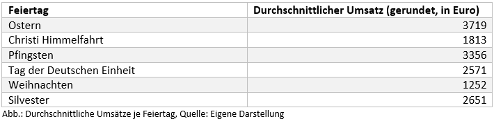

Verglichen mit den Umsätzen je Wochentag und hierbei insbesondere mit dem umsatzstärksten Sonntag (Umsatz im Durchschnitt 2414 Euro) werden an einzelnen Feiertagen außergewöhnlich hohe Umsätze erzielt. Besonders stark hervor treten Ostern und Pfingsten, doch auch die Umsätze am Tag der Deutschen Einheit und Silvester sind überdurchschnittlich stark. Nicht so erfolgreich schneiden Christi Himmelfahrt und Weihnachten ab. An Weihnachten sind die Umsätze sogar niedriger als am umsatzschwächsten Wochentag Dienstag. Es wäre hier zu überlegen, ob eine Öffnung an Weihnachten wenigstens kostendeckend ist.

### Umsatz je Jahreszeit

Gespräche mit Mitarbeitern des Hansemuseums lassen darauf schließen, dass die Jahreszeiten einen Einfluss auf die Höhe des Umsatzes haben. Insofern wird auch für diese Variable eine detailliertere Betrachtung durchgeführt.

```r
df_complete %>% group_by(Jahreszeit) %>% summarise(Umsatz_sum = sum(Umsatz)) %>% arrange(desc(Umsatz_sum))
```

```
## # A tibble: 4 x 2
##   Jahreszeit Umsatz_sum
##   <chr>           <dbl>
## 1 Sommer       1011033.
## 2 Fruehling     771358.
## 3 Herbst        693901.
## 4 Winter        675719.
```

```r
df_complete %>% group_by(Jahreszeit) %>% summarise(Umsatz_mean = mean(Umsatz)) %>% arrange(desc(Umsatz_mean))
```

```
## # A tibble: 4 x 2
##   Jahreszeit Umsatz_mean
##   <chr>            <dbl>
## 1 Sommer           2160.
## 2 Fruehling        1953.
## 3 Winter           1553.
## 4 Herbst           1545.
```

Im Sommer und im Frühling werden deutlich höhere Umsätze generiert als in den jahreszeiten Herbst und Winter. Im Sommer liegt der Umsatz durchschnittlich 40% höher verglichen mit Herbst und Winter, gegenüber dem Frühling ist der Umsatz im Sommer um 10% höher. Es ist insofern ein klarer Effekt der Jahreszeiten sichtbar.

### Umsatz je Monat

In einem weiteren Schritt werden die Umsätze je Monat untersucht, um eine differenziertere Verteilung der Umsätze im Jahresverlauf zu erhalten.

```r
df_complete %>% group_by(Monat_c) %>% summarise(Umsatz_sum = sum(Umsatz)) %>% arrange(desc(Umsatz_sum))
```

```
## # A tibble: 12 x 2
##    Monat_c   Umsatz_sum
##    <chr>          <dbl>
##  1 Juli         369957.
##  2 August       341649.
##  3 September    287659.
##  4 Oktober      262679.
##  5 März         262186.
##  6 Juni         261757.
##  7 Mai          259513.
##  8 Dezember     252793.
##  9 April        231408.
## 10 Februar      229762.
## 11 Januar       207584.
## 12 November     185063.
```

```r
df_complete %>% group_by(Monat_c) %>% summarise(Umsatz_mean = mean(Umsatz)) %>% arrange(desc(Umsatz_mean))
```

```
## # A tibble: 12 x 2
##    Monat_c   Umsatz_mean
##    <chr>           <dbl>
##  1 Juli            2387.
##  2 August          2204.
##  3 Mai             2043.
##  4 April           1928.
##  5 September       1918.
##  6 März            1900.
##  7 Juni            1745.
##  8 Oktober         1695.
##  9 Dezember        1685.
## 10 Februar         1618.
## 11 Januar          1339.
## 12 November        1234.
```

- Es gibt erkennbare Unterschiede zwischen den Umsätzen pro Monat:
  - Die Sommermonate Juli und August sind die umsatzstärksten. Eine mögliche Brgündung könnte sein, dass in den Sommermonaten sehr viele Touristen (im Verhältnis zu den Einwohner) in Schleswig-Holstein sind. Dies wäre zu überprüfen.
  - Auch einige Frühlingsmonate schneiden gut ab: Mai, April, März. Vielleicht ist dies unter anderem auch auf die Feiertage Ostern, Christi Himmelfahrt und pfingsten sowie auf die umgebenden Brückentage zurückzuführen.
  - Halb Sommer, halb Herbst, teilweise in den Sommerferien liegend, schneidet auch der September gut ab.
  - Schlechter sind die Umsätze in den Herbst- und Wintermonaten, was bei der vorangegangenen Analyse schon sichtbar wurde. Im Juli beispielsweise sind die Umsätze fast doppelt so hoch wie im November, der den umsatzschwächsten Monat darstellt.

## 4.3 Umsatz im Zeitverlauf

Von Interesse ist nun die Entwicklung der Umsätze im Zeitverlauf.Es soll geprüft werden, ob eine Trendentwicklung zu beobachten ist und ob es strukturelle Brüche in den Zeitreihen gibt. Wir betrachten dafür zunächst die Entwicklung des Gesamtumsatzes pro Jahr. Als Datenbasis verwenden wir abermals den kompletten datensatz `df_complete`.

```r
umsatz_jahr <- df_complete %>% group_by(Jahr) %>% summarise(Umsatz=sum(Umsatz))
umsatz_jahr
```

```
## # A tibble: 6 x 2
##    Jahr  Umsatz
##   <dbl>   <dbl>
## 1  2015  96956.
## 2  2016 808188.
## 3  2017 731538.
## 4  2018 678936.
## 5  2019 739272.
## 6  2020  97119.
```

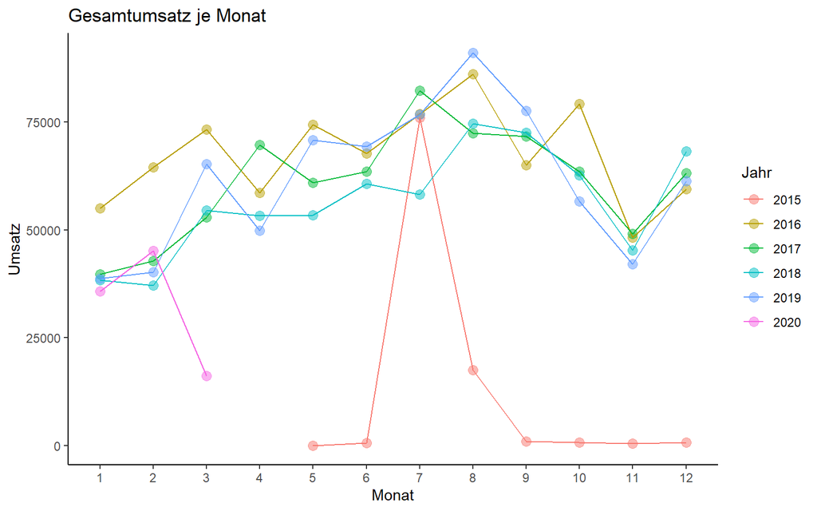

```r
umsatz_jahr_monat <- df_complete %>% mutate(Jahr=as.character(Jahr)) %>% group_by(Jahr, Monat) %>% summarise(Umsatz=sum(Umsatz)) # Variable Jahr in character umgewandelt, damit im folgenden Plot eine diskrete Farbskala in der Legende gezeigt werden kann
p_umsatz_jahr_monat <- ggplot(data = umsatz_jahr_monat, aes(x = Monat, y = Umsatz)) +
  geom_point(aes(color = Jahr), size = 3, alpha = 0.5) +
  geom_line(aes(group = Jahr, color = Jahr)) +
  scale_x_discrete(limits=c("1","2","3","4","5","6","7","8","9","10","11","12")) +
  xlab("Monat") + ylab("Umsatz") +
  labs(color = "Jahr") +
  theme_classic() +
  ggtitle("Gesamtumsatz je Monat")

p_umsatz_jahr_monat
```

Beobachtungen:

- Die Jahre 2016 bis 2019 sind weitestgehend ähnlich im Jahresverlauf.
- Die Umsätze im Jahr 2015 erscheinen ungewöhnlich. Während in der Eröffnungsphase (Eröffnung 27.05.2015) im Mai / Juni fast keine Umsätze zu verzeichnen sind, schießen sie im Juli buchstäblich durch die Decke, um dann wieder schlagartig abzusinken. In den monaten September bis Dezember sind nahezu keinerlei Umsätze zu verzeichnen, was unrealistisch erscheint. Hier ist zum einen Rücksprache mit dem hansemuseum zu halten sowie zu überlegen, ob diese Daten nicht aus den weiteren Analysen ausgeschlossen werden sollten.
- Der Verlauf für 2020 ist zu Beginn, d. h. im Januar und Februar, ähnlich zu den Umsätzen in den Vorjahren. Im März sinken die Umsatzzahlen rapide, was sehr wahrscheinlich auf den Beginn der sogenannten Coronakrise und damit einhergehenden Schließungen von öffentlichen Einrichtungen zurückzuführen ist. Da das Jahr 2020 ein sehr ungewöhnliches ist, ist zu überlegen, ob diese Daten nicht ebenfalls von der Analyse ausgeschlossen werden sollten.

**Fazit**

Aufgrund der Datenlage wäre es anzuraten, die Daten aus den Jahren 2016 - 2018 als Trainingsdaten und die Daten aus dem Jahr 2019 als Testdaten zu nutzen.

```r
Umsatz %>%
  dplyr::select(Datum, Umsatz) %>%
  group_by(Datum) %>%
  summarise(Gesamtumsatz = sum(Umsatz)) %>%
  arrange(desc(Gesamtumsatz)) %>%
  top_n(20)
```

```
## # A tibble: 20 x 2
##    Datum               Gesamtumsatz
##    <dttm>                     <dbl>
##  1 2015-07-20 00:00:00        8728
##  2 2015-07-29 00:00:00        7840.
##  3 2015-07-30 00:00:00        7672
##  4 2015-07-31 00:00:00        7209
##  5 2016-05-16 00:00:00        6407
##  6 2016-08-04 00:00:00        6290.
##  7 2016-03-26 00:00:00        5958.
##  8 2015-07-28 00:00:00        5893
##  9 2017-07-13 00:00:00        5820.
## 10 2017-07-26 00:00:00        5796.
## 11 2015-07-26 00:00:00        5629
## 12 2015-07-27 00:00:00        5542.
## 13 2019-08-16 00:00:00        5487
## 14 2017-06-05 00:00:00        5384.
## 15 2017-04-16 00:00:00        5322.
## 16 2019-08-19 00:00:00        5254.
## 17 2016-10-23 00:00:00        5020.
## 18 2017-09-10 00:00:00        4950
## 19 2016-01-03 00:00:00        4817
## 20 2019-08-08 00:00:00        4815
```

### Gesamtumsatz und Umsatz je Wochentag

Zunächst wird der Umsatz je Wochentag in den Daten untersucht. Als Basis verwenden wir die zunächst den vollständigen Datensatz `df_complete`.

```r
df_complete %>% summarise(Umsatz_sum = sum(Umsatz))
```

```
## # A tibble: 1 x 1
##   Umsatz_sum
##        <dbl>
## 1   3152010.
```

```r
df_complete %>% group_by(Wochentag_c) %>% summarise(Umsatz_sum = sum(Umsatz)) %>% arrange(desc(Umsatz_sum))
```

```
## # A tibble: 7 x 2
##   Wochentag_c Umsatz_sum
##   <chr>            <dbl>
## 1 Sonntag        601301.
## 2 Montag         509619.
## 3 Samstag        441110.
## 4 Donnerstag     430616.
## 5 Freitag        422653.
## 6 Mittwoch       410566.
## 7 Dienstag       336145.
```

```r
df_complete %>% group_by(Wochenende) %>% summarise(Umsatz_sum = sum(Umsatz)) %>% arrange(desc(Umsatz_sum))
```

```
## # A tibble: 2 x 2
##   Wochenende Umsatz_sum
##        <dbl>      <dbl>
## 1          0   2109599.
## 2          1   1042411.
```

```r
df_complete %>% group_by(Wochentag_c) %>% summarise(Umsatz_mean = mean(Umsatz)) %>% arrange(desc(Umsatz_mean))
```

```
## # A tibble: 7 x 2
##   Wochentag_c Umsatz_mean
##   <chr>             <dbl>
## 1 Sonntag           2415.
## 2 Montag            2047.
## 3 Samstag           1764.
## 4 Donnerstag        1729.
## 5 Freitag           1684.
## 6 Mittwoch          1642.
## 7 Dienstag          1350.
```

```r
df_complete %>% group_by(Wochenende) %>% summarise(Umsatz_mean = mean(Umsatz)) %>% arrange(desc(Umsatz_mean))
```

```
## # A tibble: 2 x 2
##   Wochenende Umsatz_mean
##        <dbl>       <dbl>
## 1          1       2089.
## 2          0       1690.
```

- In dem betrachteten Zeitraum hat das EHM insgesamt einen Umsatz in Höhe von 3.152.010 Euro generiert.
- Die umsatzstärksten Wochentage im gesamten betrachteten Zeitraum sind Sonntag (601.301 Euro) und Montag (509.619 Euro), der umsatzschwächste Tag ist Dienstag (336.145 Euro); die anderen Wochentage unterscheiden sich nur marginal, die Umsätze schwanken hier zwischen 410.000 - 440.000 Euro.
- Der durchschnittliche Tagesumsatz an einem Sonntag beträgt 2414 Euro, an einem Montag 2046 Euro, der an Dienstagen 1349 Euro.
- Summiert sind die Umsätze der Wochentage doppelt so hoch wie am Wochenende, mit anderen Worten wurden 2/3 der Umsätze an Wochentagen erzielt, 1/3 an Wochenendtagen. Berücksichtigt man, dass es in Summe 2.5 mal so viele Wochentage wie Wochenendtage im betrachteten Zeitraum gab, ergibt sich ein etwas anderes Bild: An den Wochenendtagen wurde im Schnitt ein Umsatz von 2089 Euro erzielt, an den Wochentagen 1690 Euro.

Nicht unberücksichtigt bleiben sollte, dass manche Feiertage immer auf den Montag fallen (Ostermontag, Pfingstmontag) und manche jahresabhängig auf einen Montag fallen können und dies auch einen gewissen Einfluss haben könnte. In einem nächsten Schritt werden insofern die durchschnittlichen Umsätze an den Feiertagen betrachtet.

### Gesamtumsatz je Feiertag

Da zu vermuten ist, dass Feiertage einen starken Effekt auf den Umsatz haben könnten, wird nun der Umsatz je Feiertag in den Daten untersucht. Als Basis verwenden wir wieder den vollständigen Datensatz `df_complete`.

```r
df_complete %>% filter(Ostern == 1) %>% summarise(Umsatz_mean = mean(Umsatz))
```

```
## # A tibble: 1 x 1
##   Umsatz_mean
##         <dbl>
## 1       3719.
```

```r
df_complete %>% filter(ChristiHimmelfahrt == 1) %>% summarise(Umsatz_mean = mean(Umsatz))
```

```
## # A tibble: 1 x 1
##   Umsatz_mean
##         <dbl>
## 1        1813
```

```r
df_complete %>% filter(Pfingsten == 1) %>% summarise(Umsatz_mean = mean(Umsatz))
```

```
## # A tibble: 1 x 1
##   Umsatz_mean
##         <dbl>
## 1       3356.
```

```r
df_complete %>% filter(TDE == 1) %>% summarise(Umsatz_mean = mean(Umsatz))
```

```
## # A tibble: 1 x 1
##   Umsatz_mean
##         <dbl>
## 1        2571
```

```r
df_complete %>% filter(Weihnachten == 1) %>% summarise(Umsatz_mean = mean(Umsatz))
```

```
## # A tibble: 1 x 1
##   Umsatz_mean
##         <dbl>
## 1       1252.
```

```r
df_complete %>% filter(Silvester == 1) %>% summarise(Umsatz_mean = mean(Umsatz))
```

```
## # A tibble: 1 x 1
##   Umsatz_mean
##         <dbl>
## 1       2651.
```

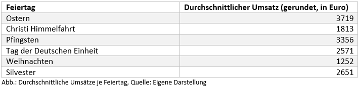

Verglichen mit den Umsätzen je Wochentag und hierbei insbesondere mit dem umsatzstärksten Sonntag (Umsatz im Durchschnitt 2414 Euro) werden an einzelnen Feiertagen außergewöhnlich hohe Umsätze erzielt. Besonders stark hervor treten Ostern und Pfingsten, doch auch die Umsätze am Tag der Deutschen Einheit und Silvester sind überdurchschnittlich stark. Nicht so erfolgreich schneiden Christi Himmelfahrt und Weihnachten ab. An Weihnachten sind die Umsätze sogar niedriger als am umsatzschwächsten Wochentag Dienstag. Es wäre hier zu überlegen, ob eine Öffnung an Weihnachten wenigstens kostendeckend ist.

### Umsatz je Jahreszeit

Gespräche mit Mitarbeitern des Hansemuseums lassen darauf schließen, dass die Jahreszeiten einen Einfluss auf die Höhe des Umsatzes haben. Insofern wird auch für diese Variable eine detailliertere Betrachtung durchgeführt.

```r
df_complete %>% group_by(Jahreszeit) %>% summarise(Umsatz_sum = sum(Umsatz)) %>% arrange(desc(Umsatz_sum))
```

```
## # A tibble: 4 x 2
##   Jahreszeit Umsatz_sum
##   <chr>           <dbl>
## 1 Sommer       1011033.
## 2 Fruehling     771358.
## 3 Herbst        693901.
## 4 Winter        675719.
```

```r
df_complete %>% group_by(Jahreszeit) %>% summarise(Umsatz_mean = mean(Umsatz)) %>% arrange(desc(Umsatz_mean))
```

```
## # A tibble: 4 x 2
##   Jahreszeit Umsatz_mean
##   <chr>            <dbl>
## 1 Sommer           2160.
## 2 Fruehling        1953.
## 3 Winter           1553.
## 4 Herbst           1545.
```

Im Sommer und im Frühling werden deutlich höhere Umsätze generiert als in den jahreszeiten Herbst und Winter. Im Sommer liegt der Umsatz durchschnittlich 40% höher verglichen mit Herbst und Winter, gegenüber dem Frühling ist der Umsatz im Sommer um 10% höher. Es ist insofern ein klarer Effekt der Jahreszeiten sichtbar.

### Umsatz je Monat

In einem weiteren Schritt werden die Umsätze je Monat untersucht, um eine differenziertere Verteilung der Umsätze im Jahresverlauf zu erhalten.

```r
df_complete %>% group_by(Monat_c) %>% summarise(Umsatz_sum = sum(Umsatz)) %>% arrange(desc(Umsatz_sum))
```

```
## # A tibble: 12 x 2
##    Monat_c   Umsatz_sum
##    <chr>          <dbl>
##  1 Juli         369957.
##  2 August       341649.
##  3 September    287659.
##  4 Oktober      262679.
##  5 März         262186.
##  6 Juni         261757.
##  7 Mai          259513.
##  8 Dezember     252793.
##  9 April        231408.
## 10 Februar      229762.
## 11 Januar       207584.
## 12 November     185063.
```

```r
df_complete %>% group_by(Monat_c) %>% summarise(Umsatz_mean = mean(Umsatz)) %>% arrange(desc(Umsatz_mean))
```

```
## # A tibble: 12 x 2
##    Monat_c   Umsatz_mean
##    <chr>           <dbl>
##  1 Juli            2387.
##  2 August          2204.
##  3 Mai             2043.
##  4 April           1928.
##  5 September       1918.
##  6 März            1900.
##  7 Juni            1745.
##  8 Oktober         1695.
##  9 Dezember        1685.
## 10 Februar         1618.
## 11 Januar          1339.
## 12 November        1234.
```

- Es gibt erkennbare Unterschiede zwischen den Umsätzen pro Monat:
  - Die Sommermonate Juli und August sind die umsatzstärksten. Eine mögliche Brgündung könnte sein, dass in den Sommermonaten sehr viele Touristen (im Verhältnis zu den Einwohner) in Schleswig-Holstein sind. Dies wäre zu überprüfen.
  - Auch einige Frühlingsmonate schneiden gut ab: Mai, April, März. Vielleicht ist dies unter anderem auch auf die Feiertage Ostern, Christi Himmelfahrt und pfingsten sowie auf die umgebenden Brückentage zurückzuführen.
  - Halb Sommer, halb Herbst, teilweise in den Sommerferien liegend, schneidet auch der September gut ab.
  - Schlechter sind die Umsätze in den Herbst- und Wintermonaten, was bei der vorangegangenen Analyse schon sichtbar wurde. Im Juli beispielsweise sind die Umsätze fast doppelt so hoch wie im November, der den umsatzschwächsten Monat darstellt.

## 4.3 Umsatz im Zeitverlauf

Von Interesse ist nun die Entwicklung der Umsätze im Zeitverlauf.Es soll geprüft werden, ob eine Trendentwicklung zu beobachten ist und ob es strukturelle Brüche in den Zeitreihen gibt. Wir betrachten dafür zunächst die Entwicklung des Gesamtumsatzes pro Jahr. Als Datenbasis verwenden wir abermals den kompletten datensatz `df_complete`.

```r
umsatz_jahr <- df_complete %>% group_by(Jahr) %>% summarise(Umsatz=sum(Umsatz))
umsatz_jahr
```

```
## # A tibble: 6 x 2
##    Jahr  Umsatz
##   <dbl>   <dbl>
## 1  2015  96956.
## 2  2016 808188.
## 3  2017 731538.
## 4  2018 678936.
## 5  2019 739272.
## 6  2020  97119.
```

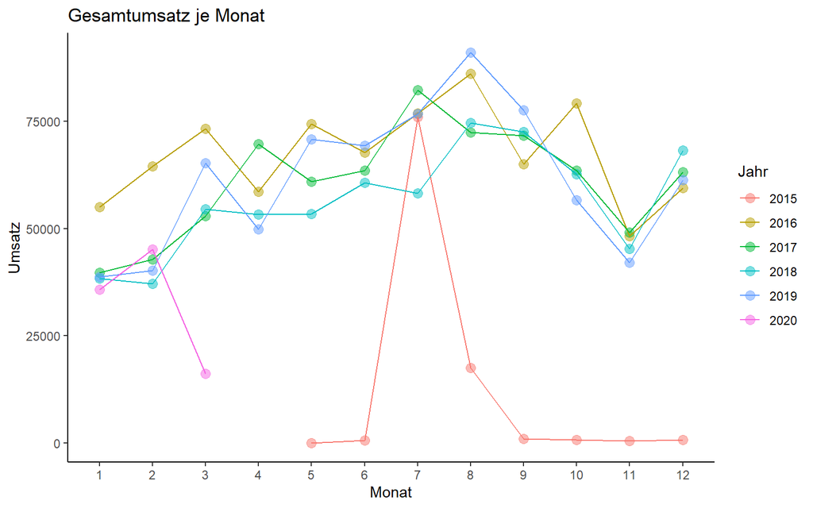

```r
umsatz_jahr_monat <- df_complete %>% mutate(Jahr=as.character(Jahr)) %>% group_by(Jahr, Monat) %>% summarise(Umsatz=sum(Umsatz)) # Variable Jahr in character umgewandelt, damit im folgenden Plot eine diskrete Farbskala in der Legende gezeigt werden kann
p_umsatz_jahr_monat <- ggplot(data = umsatz_jahr_monat, aes(x = Monat, y = Umsatz)) +
  geom_point(aes(color = Jahr), size = 3, alpha = 0.5) +
  geom_line(aes(group = Jahr, color = Jahr)) +
  scale_x_discrete(limits=c("1","2","3","4","5","6","7","8","9","10","11","12")) +
  xlab("Monat") + ylab("Umsatz") +
  labs(color = "Jahr") +
  theme_classic() +
  ggtitle("Gesamtumsatz je Monat")

p_umsatz_jahr_monat
```

Beobachtungen:

- Die Jahre 2016 bis 2019 sind weitestgehend ähnlich im Jahresverlauf.
- Die Umsätze im Jahr 2015 erscheinen ungewöhnlich. Während in der Eröffnungsphase (Eröffnung 27.05.2015) im Mai / Juni fast keine Umsätze zu verzeichnen sind, schießen sie im Juli buchstäblich durch die Decke, um dann wieder schlagartig abzusinken. In den monaten September bis Dezember sind nahezu keinerlei Umsätze zu verzeichnen, was unrealistisch erscheint. Hier ist zum einen Rücksprache mit dem hansemuseum zu halten sowie zu überlegen, ob diese Daten nicht aus den weiteren Analysen ausgeschlossen werden sollten.
- Der Verlauf für 2020 ist zu Beginn, d. h. im Januar und Februar, ähnlich zu den Umsätzen in den Vorjahren. Im März sinken die Umsatzzahlen rapide, was sehr wahrscheinlich auf den Beginn der sogenannten Coronakrise und damit einhergehenden Schließungen von öffentlichen Einrichtungen zurückzuführen ist. Da das Jahr 2020 ein sehr ungewöhnliches ist, ist zu überlegen, ob diese Daten nicht ebenfalls von der Analyse ausgeschlossen werden sollten.

**Fazit**

Aufgrund der Datenlage wäre es anzuraten, die Daten aus den Jahren 2016 - 2018 als Trainingsdaten und die Daten aus dem Jahr 2019 als Testdaten zu nutzen.

# 5. Anwendung naiver Modelle

# 6. Anwendung statistischer Modelle: Lineare Regression

# 7. Anwendung von Machine Learning Verfahren: Decision Trees

# 8. Anwendung von Machine Learning Verfahren: Support Vector Machines

# 9. Anwendung von Deep Learning Verfahren: Multilayer Perceptron

# 10. Modellvergleich

# 11. Ensemble-Methoden

# 12. Fazit und Ausblick